# Timeline

Autor: José Ángel Martínez Luque

Semestre 1 - 2021

**Datos**

- *Fuente*: http://eclr.humanities.manchester.ac.uk
- *Descripción*: dataset con con 44 observaciones correspondientes a la tasa de inflacción por pais y 14 variables correspondientes a cada pais y el año que corresponde a cada inflacción
- *Licencia*: Creative Commons Attribution-NonCommercial-ShareAlike 3.0 Unported License
- *Fecha publicación*: ultima actualización 26 julio 2016

**Visualización** eje X e Y, etiquetado, titulo, subtitulo, footer, menu informativo de paises por colores, Grafico de lineas

**Diseño** Se ha incorporado un color para cada etiqueta de pais, y un menu identificando el pais con su color.

**Preguntas**

¿Como ha evolucionado la inflación a lo largo de los años en diferentes paises?

¿Que paises han tenido mayor y menos inflacción a lo largo de los años?

**Indicad donde está colgada la visualización y cómo acceder.**

En los siguientes link se puede acceder libremente a la presentación de esta visualización de datos:

- https://jamluque-uoc.github.io/
- https://jamluque-uoc.github.io/html/timeline.html

**Definid la técnica de visualización de forma general: nombre, origen, descripción/funcionamiento, ejemplos de aplicación, etc.**

*Timeline* (linea temporal): Gráfico que identifica eventos, hitos o acontecimientos en una linea de tiempo, perfectas para contar historias

- identificación de eventos y fechas inicial y final
- eventos en orden cronológico
- Seleccionar hitos relevantes
- Agrupación de eventos similares
- Determinar escala de visualización

Se puede usar una linea de tiempo para:

- Resumir eventos
- Resaltar puntos importantes en el tiempo
- Detallar agenda o itinerario

**Describid el tipo de datos que se representa con esta técnica (datos cuantitativos, cualitativas? Qué estructura tienen que tener para cada técnica?). Explicar las limitaciones en cuanto a datos (hay medida mínima y máxima del juego de datos para esta técnica?).**

- Datos *cuantitativos* pueden ser contados, medidos o expresados utilizando números. Directo y conclusivo
- Datos *cualitativos* son descriptivos y conceptuales. Este tipo de datos puede ser categorizados. Subjetivo, interpretativo y exploratorio

Con esta tecnica se pueden representar ambos dos tipos, categorias que se quieren representar por agrupaciones y sumas o calculos de sus totales, por ejemplo.

las limitaciones vienen dadas por el conjunto de datos, si es un conjunto muy amplio de datos y se quiere representar todo, es posible que la grafica sea confusa, aqui deberiamos agrupar o seleccionar por categorias, o identificar puntos representativo de un dato concreto en el tiempo para darle mas representación en el dato.

**Hacer una representación con esta técnica de *Timeline* usando un conjunto de datos abiertos**

**Comentar brevemente la representaciones indicando qué se representa y qué aspectos muestra o demuestra cada representación.**

Los datos estan categorizados por paises, agrupados por año representando el % de inflacción de los alimentos en cada pais para ese año en concreto Se ha identificado puntos maximos y minimos en el tiempo de la inflación de unos paises.

```r
library(ggplot2)
library(xts)  # eXtensible Time Series
library(reshape2)
```

```r
food <- read.csv('data/inflaccionAlimentos.csv',na.strings = "")
```

```r
head(food)
```

```
##      X      AUS        CAN       DEN       FIN       FRA      GER       ITA
## 1 1970 4.417763  1.6072980  8.023599  1.453488  6.031746 2.268588  4.640916
## 2 1971 3.213680  0.5130398  6.444566  4.297994  7.705641 3.837435  4.231579
## 3 1972 5.320289  7.6988520  9.132889  9.428607  9.853694 5.707157  7.244328
## 4 1973 7.187416 15.0079000 13.399150 11.932340 12.505830 7.523233 11.965600
## 5 1974 8.135121 15.7967000 11.774460 15.953250 11.482690 4.760598 19.585080
## 6 1975 6.048906 12.5444800 11.164690 20.666410 11.096360 5.264536 19.687730
##         JAP      NET       SWE       SWI        UK        US
## 1  9.218785 3.452534  8.478838  2.439797  9.772689  4.996713
## 2  4.864372 4.671392  9.196856  6.518713 11.468810  2.421206
## 3  3.240634 6.586642  9.080355  6.410163  8.924400  4.442633
## 4 13.499150 7.926653  5.778154  6.105881 15.367740 16.292680
## 5 29.505860 7.123746  6.156134 10.776060 18.018140 14.848990
## 6 12.585130 8.054949 11.799710  6.169830 24.970660  8.254200
```

```r
food <- xts(food[,-1], order.by=as.Date(paste0(food[,1],"-01-01")))
```

```r
temp <- data.frame(index(food),stack(as.data.frame(coredata(food))))
```

```r
names(temp)[1] <- "year"
names(temp)[2] <- "infla"
names(temp)[3] <- "Pais"
```

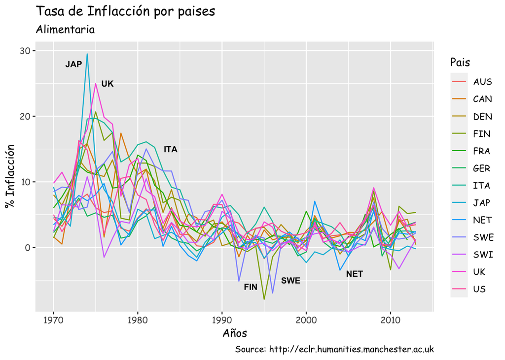

```r
ggplot(temp,aes(x=year, y=infla, color=Pais)) +
  geom_line(na.rm = TRUE) +
  annotate("text",x=as.Date("1972-06-01"),y=28,label="JAP",fontface="bold",size=3) +
  annotate("text",x=as.Date("1976-06-01"),y=25,label="UK",fontface="bold",size=3)  +
  annotate("text",x=as.Date("1998-03-01"),y=-5,label="SWE",fontface="bold",size=3) +
  annotate("text",x=as.Date("1983-12-01"),y=15,label="ITA",fontface="bold",size=3) +
  annotate("text",x=as.Date("1993-06-01"),y=-6,label="FIN",fontface="bold",size=3) +
  annotate("text",x=as.Date("2005-10-01"),y=-4,label="NET",fontface="bold",size=3) +
  labs(title="Tasa de Inflacción por paises",
       subtitle = "Alimentaria",
       caption = "Source: http://eclr.humanities.manchester.ac.uk",
       y= "% Inflacción", x= "Años") +
  theme(text=element_text(family="Comic Sans MS"))
```